# Using msarg to construct ms models of migration.

Peter Ralph

May 1, 2015

Here are some simpler, probably better, specific examples:

1. Appearance, and disappearance, of a barrier
2. Parallel universes
3. Sudden appearance, and gradual retreat, of a glacier

# Forwards and Reverse Time

The migration rates of `ms` are: “$m_{ij}$ the fraction of subpopulation $i$ which is made up of migrants from subpopulation $j$ each generation”. But to translate to more natural units of migration, we need to scale these rates by population size; as the `ms` documentation notes: adding `-n 3 0.5` has the effect that: “the number of migrant copies arriving each generation from a particular population, or from all other subpopulations, to population 3 is half as large as a consequence of this command. This is because the fraction of migrants is the same, but the total number of individuals is half what it would have been without the -n command.” In other words, the `-m` of `ms` gives the probability of migration of a *lineage*, in reverse time, not an individual.

To make this more intuitive, and along the way make it easier to specify range expansions, we’re going to be specifying migration rates in *forwards time*. The migration rate $m_{ij}$ of `ms` is: $m_{ij} = \frac{ \text{(number of inmigrants to $i$ from $j$ per generation)} }{ \text{(size of population $i$)} }$ or equivalently $m_{ij} = \text{(probability an indiv from $j$ will migrate to $i$ per generation)} \times \frac{ \text{(size of population $j$)} }{ \text{(size of population $i$)} }$ We’ll specify things in terms of *probability an indiv from $j$ will migrate to $i$ per generation*, which we call $\tilde m_{ji}$, and then when outputting to `ms` format, compute $m_{ij} = \tilde m_{ji} n_j/n_i$.

After this, as populations get smaller (back in time), the lineages tend to move out of them; so rather than dissappearing populations (with `-ej` and the like) we can just make them very small, and lineages will instantly do the right thing.

# Population growth

`ms` allows specification of population growth rates. These don’t interact with migration in the way we’d want them to (see above); so we won’t use this option.

# Grid Arrays

The basic object is the population model for a given chunk of time. We’ll just deal with sets of populations on a grid, so that will be a `gridArray` object. Let’s make one, with two layers, of a 30 x 20 grid, within-layer migration rates of 1 and between-layer rates of 0.1:

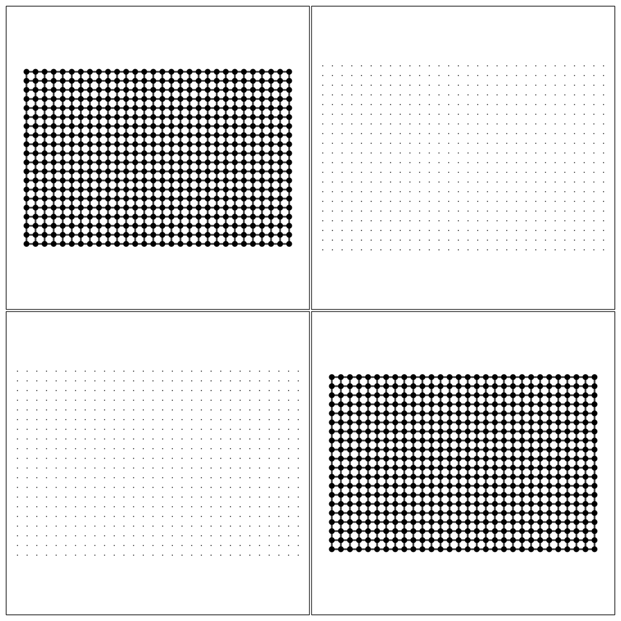

```r
ga <- grid_array(nlayers=2,nrow=30,ncol=20,N=1000,mig.rate=1,admix.rate=0.1)
plot(ga)
```

In the plot, the diagonal shows arrows weighted by migration rates within a given layer, and offdiagonals show circles with size proportional to the “admixture” migration between the relevant layers. This looks pretty boring because all the migration rates are the same, and isn’t showing between-layer migration rates at the moment. So we have something to look at, let’s increase migration rates on one layer, and then restrict each layer to a circle centered on the two corners:

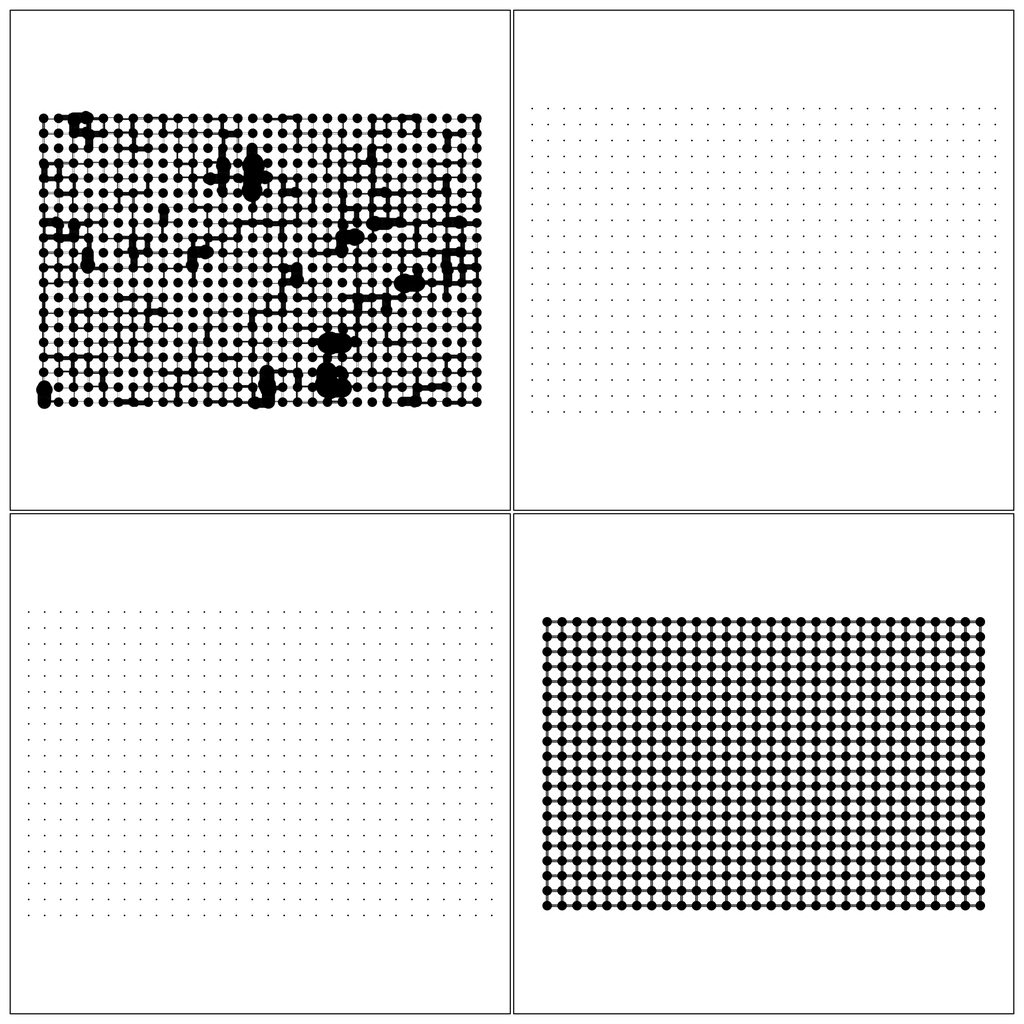

```r
ga <- modify_migration(ga,layer=1,doutM=rexp(ncol(ga)*nrow(ga)),dinM=rexp(nrow(ga)*ncol(ga)))
plot(ga)
```

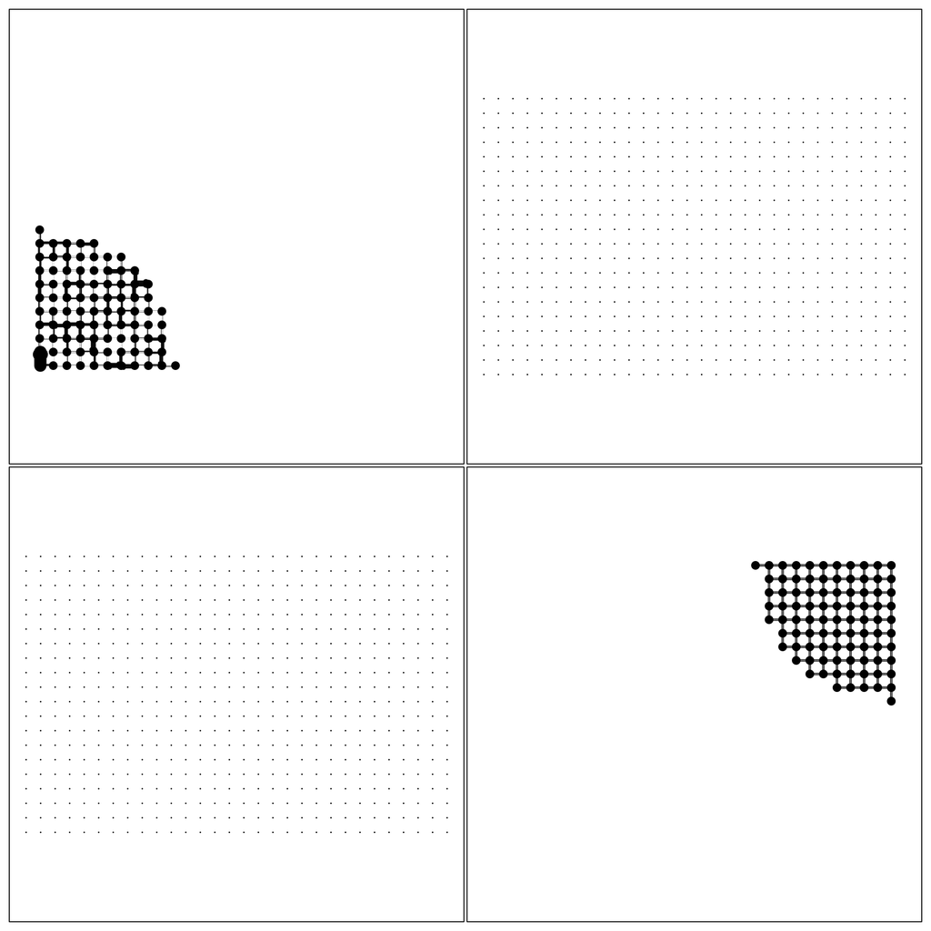

```r
ga <- restrict_patch(ga,layer=1,xy=c(1,1),r=10)
ga <- restrict_patch(ga,layer=2,xy=c(nrow(ga),ncol(ga)),r=10)
plot(ga)
```

Note that each population also has an associated “exponential growth” rate.

We can also add barriers:

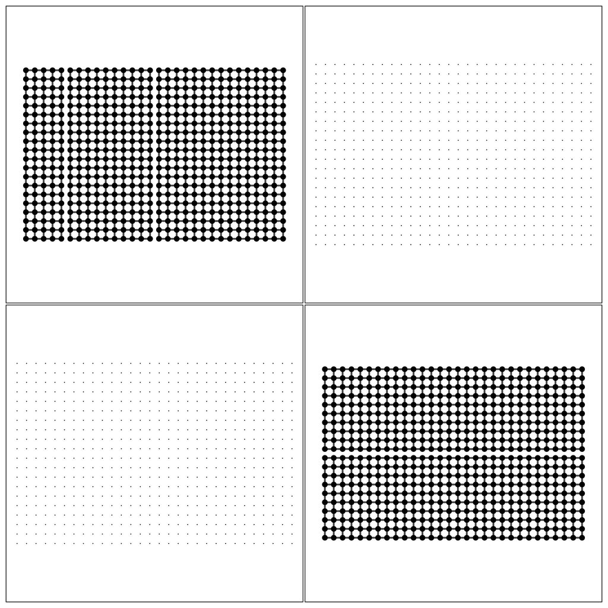

```r
ga <- grid_array(nlayers=2,nrow=30,ncol=20,N=1000,mig.rate=1,admix.rate=0.1)
ga <- add_barrier(ga, layer=1, rows=c(5,15))
ga <- add_barrier(ga, layer=2, cols=10)
plot(ga)
```

# Demographies

Now, here’s an example of stringing these together into a model, with four model changes, and various `dt` between them:

```r
dem <- demography( grid_array(nlayers=2,nrow=30,ncol=20,N=1000,mig.rate=1,admix.rate=0.1) )
dem[[1]] <- modify_migration(dem[[1]],layer=1,doutM=rexp(prod(dim(dem[[1]])[1:2])),dinM=rexp(prod(dim(dem[[1]])[1:2])))
dem <- add_to_demography( dem, dt=2, add_barrier, layer=1, rows=10 )
dem <- add_to_demography( dem, dt=1, restrict_patch, layer=1,xy=c(1,1),r=10 )
dem[[3]] <- restrict_patch(dem[[3]],layer=2,xy=c(nrow(dem[[1]]),ncol(dem[[1]])),r=10)
dem <- add_to_demography( dem, dt=2, identity )
dem[[4]] <- dem[[1]]
cat("t=",0,"\n")
```

```
## t= 0
```

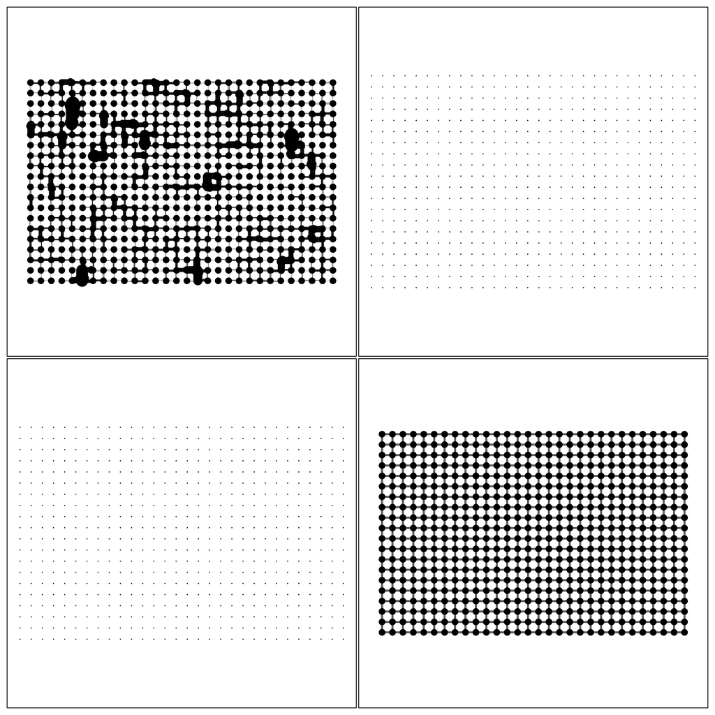

```r
plot(dem[[1]])
```

```r
cat("t=",dem@t[1],"\n")
```

```
## t= 2
```

[figure not shown]

```r
plot(dem[[2]])
```

```r
cat("t=",dem@t[2],"\n")
```

```
## t= 3
```

[figure not shown]

```r
plot(dem[[3]])
```

```r
cat("t=",dem@t[3],"\n")
```

```
## t= 5
```

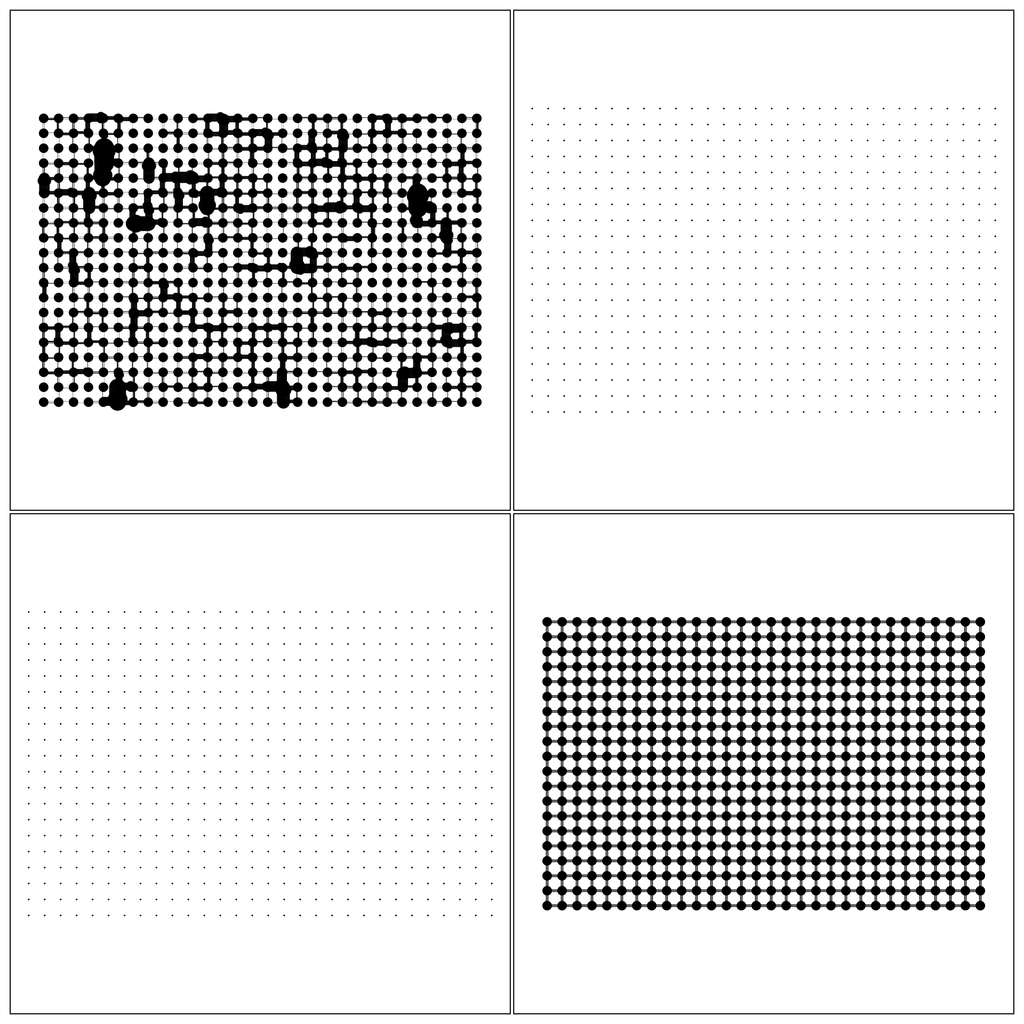

```r
plot(dem[[4]])
```

We also have a function to convert these to ms command line parameters. To check this, let’s try a smaller model.

```r
dem <- demography( grid_array(nlayers=2,nrow=3,ncol=2,N=1000,mig.rate=1,admix.rate=0.1) )
dem[[1]] <- modify_migration(dem[[1]],layer=1,doutM=rexp(ncol(dem[[1]])),dinM=rexp(nrow(dem[[1]])))
dem <- add_to_demography( dem, dt=1, restrict_patch, layer=1,xy=c(1,1),r=1 )
dem[[2]] <- restrict_patch(dem[[2]],layer=2,xy=c(nrow(dem[[1]]),ncol(dem[[1]])),r=1)
print( msarg(dem,nsamp=cbind(row=1,col=1,layer=1,n=2)) )
```

```
## -I 12 2 0 0 0 0 0 0 0 0 0 0 0
## -n 1 1000
## -n 2 1000
## -n 3 1000
## -n 4 1000
## -n 5 1000
## -n 6 1000
## -n 7 1000
## -n 8 1000
## -n 9 1000
## -n 10 1000
## -n 11 1000
## -n 12 1000
## -g 1 0
## -g 2 0
## -g 3 0
## -g 4 0
## -g 5 0
## -g 6 0
## -g 7 0
## -g 8 0
## -g 9 0
## -g 10 0
## -g 11 0
## -g 12 0
## -m 2 1 11.5467892107367
## -m 4 1 0.35978027536158
## -m 7 1 0.1
## -m 1 2 0.0203434782298047
## -m 3 2 0.129037245111571
## -m 5 2 0.652903649864324
## -m 8 2 0.1
## -m 2 3 11.5467892107367
## -m 6 3 2.28206086755236
## -m 9 3 0.1
## -m 1 4 0.0203434782298047
## -m 5 4 0.652903649864324
## -m 10 4 0.1
## -m 2 5 11.5467892107367
## -m 4 5 0.35978027536158
```

[output cut: 48 more lines]

```
## -em 1 3 6 0.129037245111571
## -em 1 5 6 0.652903649864324
## -em 1 12 6 9.99000999000999e-05
## -em 1 1 7 9.99000999000999e-05
## -em 1 2 8 9.99000999000999e-05
## -em 1 9 8 0.000999000999000999
## -em 1 11 8 0.000999000999000999
## -em 1 3 9 100.1
## -em 1 8 9 1001
## -em 1 4 10 9.99000999000999e-05
## -em 1 11 10 0.000999000999000999
## -em 1 5 11 100.1
## -em 1 8 11 1001
## -em 1 10 11 1001
## -em 1 6 12 100.1
```

*To-do:* make better specification of how many samples per which population.

# Check on the migration rates

```r
popsizes <- c(1e3,1e5)
ms.trees <- lapply( popsizes, function (popsize) {
        ga <- grid_array(
                nlayers=2,     # two layers
                nrow=1,ncol=1, # but only a 1x1 "grid" on each layer
                mig.rate=1,    # migration within each layer; does nothing here
                admix.rate=matrix(c(0,0,1,0),nrow=2),  # migration from layer 1 to layer 2, but not vice-versa
                N=c(popsize,1e-4)       # first pop is 1000x the second
            )
        ms.output <- run_ms( ga,
                nsamp=c(5,2),    # five sampled lineages from each population
                trees=TRUE,      # output the tree (in newick)
                tofile=FALSE,     # don't bother putting this in a file
                scale.migration=FALSE  # don't scale migration rates by pop sizes, to investigate what ms does by itself
            )
        cat( paste( ms.output, collapse="\n" ), "\n" )  # here's the output
        read.tree(text=ms.output[5])
    } )
```

```
## ms 7 1 -T -I 2 5 2 -n 1 1000 -n 2 1e-04 -g 1 0 -g 2 0 -m 1 2 1
## 62854 20672 42556
##
## //
## (2:1.788,(3:0.758,(4:0.134,(5:0.071,(1:0.015,(6:0.000,7:0.000):0.015):0.057):0.062):0.624):1.030);
## ms 7 1 -T -I 2 5 2 -n 1 1e+05 -n 2 1e-04 -g 1 0 -g 2 0 -m 1 2 1
## 53860 29884 42156
##
## //
## (4:1.726,(2:0.876,(3:0.801,(1:0.283,(5:0.264,(6:0.000,7:0.000):0.264):0.018):0.518):0.075):0.850);
```

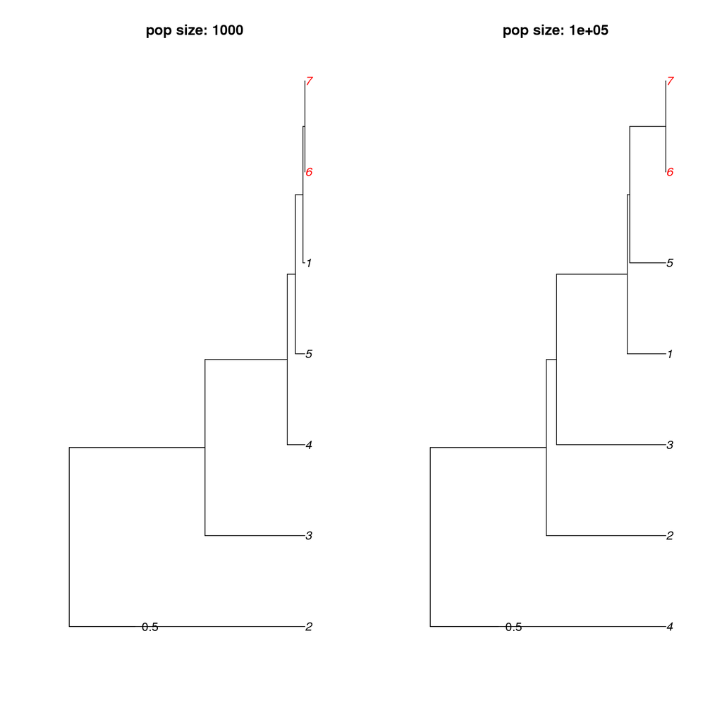

```r
layout(t(1:2))
plot(ms.trees[[1]], tip.color=ifelse(as.numeric(ms.trees[[1]]$tip.label)>5,"red","black"), main=paste("pop size:",popsizes[1]) )
add.scale.bar()
plot(ms.trees[[2]], tip.color=ifelse(as.numeric(ms.trees[[2]]$tip.label)>5,"red","black"), main=paste("pop size:",popsizes[2]) )
add.scale.bar()
```

The trees look about the same (on the same scale), certainly not different by a factor of 100, as you’d get if migration rates of lineages was affected by the difference in population size.

Is the same true for the source population? Yep:

```r
popsizes <- c(1e-2,1e-5)
ms.trees <- lapply( popsizes, function (popsize) {
        ga <- grid_array(
                nlayers=2,     # two layers
                nrow=1,ncol=1, # but only a 1x1 "grid" on each layer
                mig.rate=1,    # migration within each layer; does nothing here
                admix.rate=matrix(c(0,0,1,0),nrow=2),  # migration from layer 1 to layer 2, but not vice-versa
                N=c(1e4,popsize)       # first pop is 1000x the second
            )
        ms.output <- run_ms( ga,
                nsamp=c(5,2),    # five sampled lineages from each population
                trees=TRUE,      # output the tree (in newick)
                tofile=FALSE,     # don't bother putting this in a file
                scale.migration=FALSE  # don't scale migration rates by pop sizes, to investigate what ms does by itself
            )
        cat( paste( ms.output, collapse="\n" ), "\n" )  # here's the output
        read.tree(text=ms.output[5])
    } )
```

```
## ms 7 1 -T -I 2 5 2 -n 1 10000 -n 2 0.01 -g 1 0 -g 2 0 -m 1 2 1
## 16525 57698 56362
##
## //
## (4:2.374,(3:1.099,(5:1.023,(1:0.128,(2:0.080,(6:0.000,7:0.000):0.080):0.048):0.896):0.076):1.275);
## ms 7 1 -T -I 2 5 2 -n 1 10000 -n 2 1e-05 -g 1 0 -g 2 0 -m 1 2 1
## 26052 32564 57890
##
## //
## (1:1.392,(4:0.441,(5:0.357,(3:0.289,(2:0.164,(6:0.000,7:0.000):0.164):0.124):0.068):0.084):0.951);
```

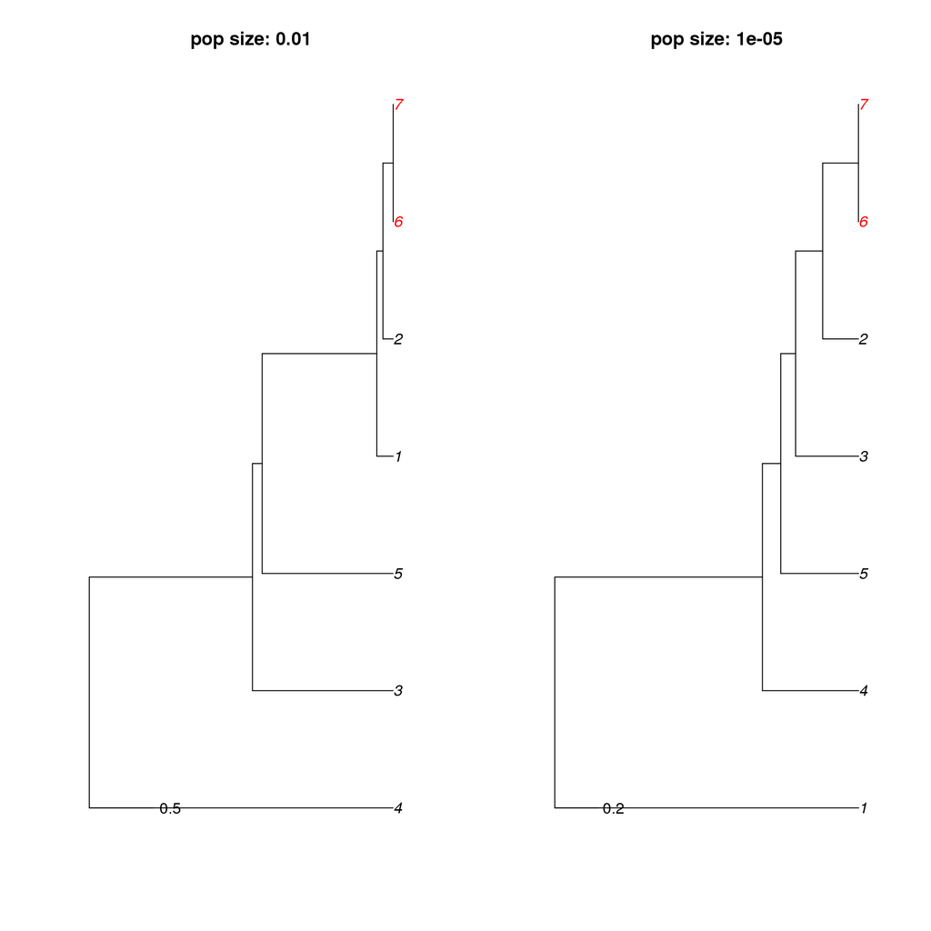

```r
layout(t(1:2))
plot(ms.trees[[1]], tip.color=ifelse(as.numeric(ms.trees[[1]]$tip.label)>5,"red","black"), main=paste("pop size:",popsizes[1]) )
add.scale.bar()
plot(ms.trees[[2]], tip.color=ifelse(as.numeric(ms.trees[[2]]$tip.label)>5,"red","black"), main=paste("pop size:",popsizes[2]) )
add.scale.bar()
```